# Final Tutorial- Jacob Gartenstein

https://jgartens.github.io

This tutorial focuses on the Spotify Audio Features data set, described below.

Spotify Audio Features – Available on Kaggle, posted by tomigelo

Link: https://www.kaggle.com/tomigelo/spotify-audio-features/data

My question when examining this data has to do with the generation of some of the song 'scores' that spotify calculates and using to rate songs on their musical features and feel. How are these scores generated? Are they grounded in other quantitative data about the songs that spotify has also made available?

## Extraction, Transform, and Load (ETL) + Exploratory Data Analysis

I'll be using the Spotify data set from April 2019 because it's the largest and most recent. Since the data set comes as a CSV file, it's easy to load into Pandas - which I do below.

```python
import pandas as pd
import numpy as np
import seaborn as sns
!pip install lxml
import requests
from bs4 import BeautifulSoup
import matplotlib.pyplot as plt
```

```python
spotify_df = pd.read_csv("./data/SpotifyAudioFeaturesApril2019.csv")
spotify_df.head()
```

|  | artist_name | track_id | track_name | acousticness | danceability | duration_ms | energy | instrumentalness | key | liveness | loudness | mode | speechiness | tempo | time_signature | valence | popularity |
| --- | --- | --- | --- | --- | --- | --- | --- | --- | --- | --- | --- | --- | --- | --- | --- | --- | --- |
| 0 | YG | 2RM4jf1Xa9zPgMGRDiht8O | Big Bank feat. 2 Chainz, Big Sean, Nicki Minaj | 0.005820 | 0.743 | 238373 | 0.339 | 0.000 | 1 | 0.0812 | -7.678 | 1 | 0.4090 | 203.927 | 4 | 0.118 | 15 |
| 1 | YG | 1tHDG53xJNGsItRA3vfVgs | BAND DRUM (feat. A$AP Rocky) | 0.024400 | 0.846 | 214800 | 0.557 | 0.000 | 8 | 0.2860 | -7.259 | 1 | 0.4570 | 159.009 | 4 | 0.371 | 0 |
| 2 | R3HAB | 6Wosx2euFPMT14UXiWudMy | Radio Silence | 0.025000 | 0.603 | 138913 | 0.723 | 0.000 | 9 | 0.0824 | -5.890 | 0 | 0.0454 | 114.966 | 4 | 0.382 | 56 |
| 3 | Chris Cooq | 3J2Jpw61sO7l6Hc7qdYV91 | Lactose | 0.029400 | 0.800 | 125381 | 0.579 | 0.912 | 5 | 0.0994 | -12.118 | 0 | 0.0701 | 123.003 | 4 | 0.641 | 0 |
| 4 | Chris Cooq | 2jbYvQCyPgX3CdmAzeVeuS | Same - Original mix | 0.000035 | 0.783 | 124016 | 0.792 | 0.878 | 7 | 0.0332 | -10.277 | 1 | 0.0661 | 120.047 | 4 | 0.928 | 0 |

This data is already upkept pretty well - each row records a single song and each column records specific attributes for that song. I'm going to drop the track_id, key, and popularity columns, which we won't need to anylize the traits of the music.

```python
spotify_df = spotify_df.drop(columns = ['track_id', 'key', 'popularity'])
spotify_df.head()
```

|  | artist_name | track_name | acousticness | danceability | duration_ms | energy | instrumentalness | liveness | loudness | mode | speechiness | tempo | time_signature | valence |
| --- | --- | --- | --- | --- | --- | --- | --- | --- | --- | --- | --- | --- | --- | --- |
| 0 | YG | Big Bank feat. 2 Chainz, Big Sean, Nicki Minaj | 0.005820 | 0.743 | 238373 | 0.339 | 0.000 | 0.0812 | -7.678 | 1 | 0.4090 | 203.927 | 4 | 0.118 |
| 1 | YG | BAND DRUM (feat. A$AP Rocky) | 0.024400 | 0.846 | 214800 | 0.557 | 0.000 | 0.2860 | -7.259 | 1 | 0.4570 | 159.009 | 4 | 0.371 |
| 2 | R3HAB | Radio Silence | 0.025000 | 0.603 | 138913 | 0.723 | 0.000 | 0.0824 | -5.890 | 0 | 0.0454 | 114.966 | 4 | 0.382 |
| 3 | Chris Cooq | Lactose | 0.029400 | 0.800 | 125381 | 0.579 | 0.912 | 0.0994 | -12.118 | 0 | 0.0701 | 123.003 | 4 | 0.641 |
| 4 | Chris Cooq | Same - Original mix | 0.000035 | 0.783 | 124016 | 0.792 | 0.878 | 0.0332 | -10.277 | 1 | 0.0661 | 120.047 | 4 | 0.928 |

The code below is used to scrape a table from Spotify's API documentation found at the URL in the code below. This table contains dtypes and descriptions of each column key in the main dataset (above).

```python
URL = "https://developer.spotify.com/documentation/web-api/reference/tracks/get-audio-features/"

r = requests.get(URL)
html_page = r.content
soup = BeautifulSoup(html_page, 'html.parser')

#soup.prettify()
```

```python
table = soup.findAll('table')[2] #the table we want is the 3rd one on the page

table_str = str(table)
table_body = table.find('tbody')

spotify_features_df = pd.read_html(table_str, flavor = None)
spotify_features_df[0]

spotify_features_df = spotify_features_df[0]
spotify_features_df = spotify_features_df.drop([1, 13, 14,15,16,17]) #removing unnecasary entries that aren't in the original dataset
spotify_features_df['Value Description'] = spotify_features_df['Value Description'].str.replace(r'The distribution of values for this feature look like this:', '') #removing unnecasary text from certain entries' Value Descriptions
```

```python
pd.set_option('display.max_colwidth', -1) #set option to display full text in the table

display(spotify_features_df)
```

|  | Key | Value Type | Value Description |
| --- | --- | --- | --- |
| 0 | duration_ms | int | The duration of the track in milliseconds. |
| 2 | mode | int | Mode indicates the modality (major or minor) of a track, the type of scale from which its melodic content is derived. Major is represented by 1 and minor is 0. |
| 3 | time_signature | int | An estimated overall time signature of a track. The time signature (meter) is a notational convention to specify how many beats are in each bar (or measure). |
| 4 | acousticness | float | A confidence measure from 0.0 to 1.0 of whether the track is acoustic. 1.0 represents high confidence the track is acoustic. |
| 5 | danceability | float | Danceability describes how suitable a track is for dancing based on a combination of musical elements including tempo, rhythm stability, beat strength, and overall regularity. A value of 0.0 is least … |
| 6 | energy | float | Energy is a measure from 0.0 to 1.0 and represents a perceptual measure of intensity and activity. Typically, energetic tracks feel fast, loud, and noisy. For example, death metal has high energy, whi… |
| 7 | instrumentalness | float | Predicts whether a track contains no vocals. “Ooh” and “aah” sounds are treated as instrumental in this context. Rap or spoken word tracks are clearly “vocal”. The closer the instrumentalness value is… |
| 8 | liveness | float | Detects the presence of an audience in the recording. Higher liveness values represent an increased probability that the track was performed live. A value above 0.8 provides strong likelihood that the… |
| 9 | loudness | float | The overall loudness of a track in decibels (dB). Loudness values are averaged across the entire track and are useful for comparing relative loudness of tracks. Loudness is the quality of a sound that… |
| 10 | speechiness | float | Speechiness detects the presence of spoken words in a track. The more exclusively speech-like the recording (e.g. talk show, audio book, poetry), the closer to 1.0 the attribute value. Values above 0.… |
| 11 | valence | float | A measure from 0.0 to 1.0 describing the musical positiveness conveyed by a track. Tracks with high valence sound more positive (e.g. happy, cheerful, euphoric), while tracks with low valence sound mo… |
| 12 | tempo | float | The overall estimated tempo of a track in beats per minute (BPM). In musical terminology, tempo is the speed or pace of a given piece and derives directly from the average beat duration. |

Now that we know what all the song description keys refer to, let's see generally how they are related. The code below calculates and displays the correlation between each quantitative variable in the original dataset.

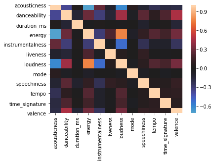

```python
correlation = spotify_df[spotify_df.columns.tolist()].corr()
sns.heatmap(correlation, center = 0)
```

This chart displays the correlation between all the quantifiable variables in the set. Black indicates no correlation. Blue hue indicates negative correlation and red hue indicates positive correlation.

This plot largely follows common sense. Variables like key or duration (ms) wouldn't be correlated with variables that describe the feel of the music like acousticness, danceability, energy, etc etc. On the other hand, it makes sense that energy and loudness are positively correlated, and that variables speechiness and instrumentalness are negatively correlated.

Basically -- nothing too suprising here.

Next we'll view the distributions of the different variables.

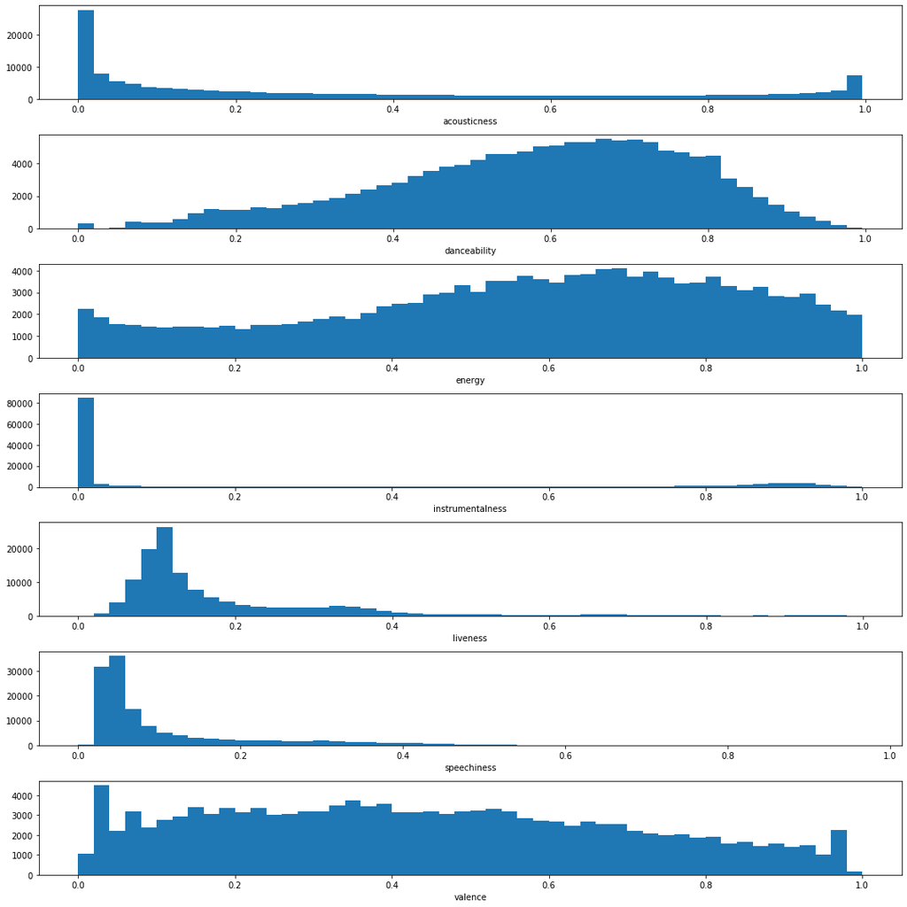

```python
columns = spotify_df.columns.tolist()
# I'm going to remove the columns for which the distributions don't make sense or don't matter

columns = columns[2:]

#seperating attributes which are 0 -1 from others for display purposes
columns_01 = columns[0:2] + columns[3:6]
columns_01.append(columns[8])
columns_01.append(columns[11])
columns_other = columns[9:11]
columns_other.append(columns[2])
columns_other.append(columns[6])
columns_other.append(columns[7])


fig, axs = plt.subplots(7,1,figsize=(15,15))
a = axs.ravel()

for idx,ax in enumerate(a):
    ax.hist(spotify_df[columns_01[idx]], bins=50)
    ax.set_xlabel(columns_01[idx])

plt.tight_layout()
```

The graphs above display the distributions of the variables for which spotify calculates their own score for each song. These variables are all measured between 0 - 1. The graphs below show the distributions for the variables that descibe the song itself,

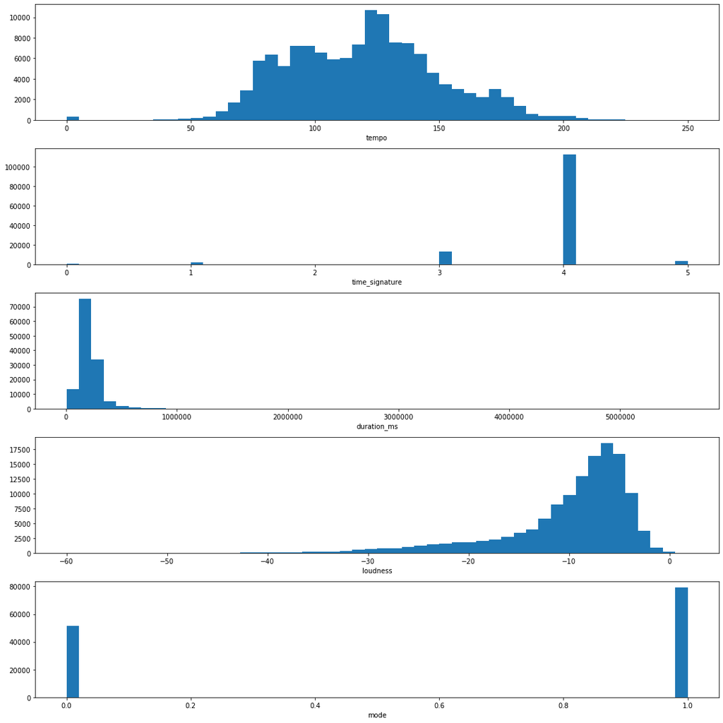

```python
fig, axs = plt.subplots(5, 1 ,figsize=(15,15))
a = axs.ravel()

for idx,ax in enumerate(a):
    ax.hist(spotify_df[columns_other[idx]], bins=50)
    ax.set_xlabel(columns_other[idx])

plt.tight_layout()
```

There's a lot of information displayed in these various distributions. I see three main trends that are present for different variables:

- centered around 0 and 1
- more or less evenly distributed
- centered around either 0 or 1

Most of the variables clearly display one or more of these trends. Acousticness and instramentalness are grouped around 0 and 1. Danceability and energy are more evenly spread but still have clear peaks. Liveliness and speachiness are grouped more around 0.

Loudness has an interesting scale because it's measuring in decibles, which are measured below zero. Tempo measures beats per minute. Time signiture measures beat per measure, of which it seems they measure only the lowest factor (no 6 or 8 or 10, intertestingly enough).

## Analysis

In this tutorial, I am going to measure the predictability of certain variables which describe the feel or sound of the music based on variables which technically describe the music itself. To me, the former set of variables are more subjective - spotify has developed algorithms to assign songs with a score. The latter set of variables are more factual - a song might be in 4/4 time and play at 140 bpm, with an average loudness of -10 db. These traits are more or less undisputable. In this process, I will basically be attemping to reverse engineer spotify's scores given all the concrete data about the music that they also provide in the API.

I'm going to focus on three 'score' variables - danceability, energy, and valence - and see what their relationships with factual variables can tell us, and if it's possible to make predications between these two sets of variables.

First I'll start by calculating and viewing some specific correlations between these variables. This correlation matrix contains the same information as the heatmap from above, but narrows it down to our variables of focus.

Pay specific attention to the relationships between 'score' and 'factual' variables.  
I predict that energy and tempo will be positively correlated. I also predict that mode and valence will be extremely positively correlated.

Generally, my hypothesis is that the scores will not be easy to reverse engineer given the other, more 'factual' data that spotify provides. This is my hunch because the 'score' variables aren't ones that could be described easily using only the other provided variables. For instance, it's difficult to identify a range of tempos that make a song 'more danceable' - that's more subjective.

```python
variables = ['danceability', 'energy', 'valence', 'loudness', 'tempo', 'time_signature', 'mode']
spotify_df[variables].corr()
```

|  | danceability | energy | valence | loudness | tempo | time_signature | mode |
| --- | --- | --- | --- | --- | --- | --- | --- |
| danceability | 1.000000 | 0.286196 | 0.461468 | 0.431554 | 0.081791 | 0.206328 | -0.057912 |
| energy | 0.286196 | 1.000000 | 0.314768 | 0.766697 | 0.229930 | 0.165030 | -0.069263 |
| valence | 0.461468 | 0.314768 | 1.000000 | 0.319881 | 0.104857 | 0.069162 | 0.011082 |
| loudness | 0.431554 | 0.766697 | 0.319881 | 1.000000 | 0.223067 | 0.179679 | -0.036081 |
| tempo | 0.081791 | 0.229930 | 0.104857 | 0.223067 | 1.000000 | 0.083759 | -0.000249 |
| time_signature | 0.206328 | 0.165030 | 0.069162 | 0.179679 | 0.083759 | 1.000000 | -0.036244 |
| mode | -0.057912 | -0.069263 | 0.011082 | -0.036081 | -0.000249 | -0.036244 | 1.000000 |

Next I'll conjur some visuals of specific relationships.

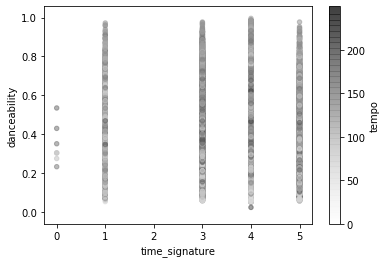

```python
spotify_df.plot.scatter(x = 'time_signature', y = 'danceability', c = 'tempo', alpha = 0.5, sharex=False)
```

Pretty even spread of danceability across tempo and time signature.

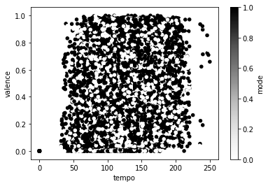

```python
spotify_df.plot.scatter(x = 'tempo', y = 'valence', c = 'mode', sharex = False)
```

What a mess! Not much to see here.

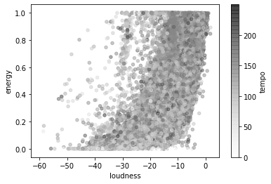

```python
spotify_df.plot.scatter(x = 'loudness', y = 'energy', c = 'tempo', alpha = 0.5, sharex = False)
```

Finally a positive correlation, though tempo doesn't seem to have much correlation with energy or loudness.

These visuals aren't particularly clear or helpful, illustrating yet again the lack of any extreme correlations between the sets of subjective and non subjective variables. This doesn't bode well for predicting future values of subjective variables from non subjective variables, but this is exactly what we'll try to do next.

Note: The source for much of this code is lab11 - ModelErrorandTuning

```python
from sklearn.feature_extraction import DictVectorizer
from sklearn.preprocessing import StandardScaler
from sklearn.neighbors import KNeighborsRegressor
from sklearn.pipeline import Pipeline
from sklearn.model_selection import cross_val_score
```

After several trials (and leaving my computer running over night), I determined that the data set is too large to run through these processes in a reasonable amount of time. I implement a three part solution to address this problem:

- reducing the data set to 1/6 of its original size
- slightly truncating the range of k values which are tested
- performing 5 fold cross validation rather than 10 fold

```python
spotify_df_1 = np.array_split(spotify_df, 6)[0]
```

```python
features = ["loudness", "tempo",
            "time_signature", "mode"] #including the relevant 'non-subjective' variables

X_dict = spotify_df_1[features].to_dict(orient="records")

# specify the pipeline
vec = DictVectorizer(sparse=False)
scaler = StandardScaler()
```

```python
def get_cv_error(k, y):
    model = KNeighborsRegressor(n_neighbors=k)
    pipeline = Pipeline([("vectorizer", vec), ("scaler", scaler), ("fit", model)])
    mse = np.mean(-cross_val_score(
        pipeline, X_dict, y,
        cv=5, scoring='neg_mean_squared_error'
    ))
    return mse
#Here I define a function (taken from lab11) that will be used to test the optimal k value to minimize MSE for each variable being tested
```

Next I create a loop which will return the root mean squared error of three variables, danceability, energy, and valence, using several steps:

- create a model using the same four variables listed above as features for prediction and the assigned y variable
- calculate the best k value to minimize error for each y value
- use 5 fold cross validation to run 5 trials of prediction using the optimized k value
- average the trials to optain a final root mean squared error for each y variable

```python
def get_rmse(y):
    #applying the above function for y and k 10-40 to optimize k
    ks = pd.Series(range(10, 41))
    ks.index = range(10, 41)
    test_errs = ks.apply(get_cv_error, args=(y,))

    #assigning optimized k as k for the remainder of trials
    my_k = test_errs.idxmin()

    #creating pipeline model using optimized k
    model = KNeighborsRegressor(n_neighbors=my_k)
    pipeline = Pipeline([("vectorizer", vec), ("scaler", scaler), ("fit", model)])

    #calculating scores for 5 fold cross validation
    scores = cross_val_score(pipeline, X_dict, y,
                         cv=5, scoring="neg_mean_squared_error")

    #calculating and returning mean of scores
    return np.sqrt(np.mean(-scores))
```

Valence, energy, and danceability are all measured between 0 - 1, so I'll run the function for each to determine which is the most easily predictable.

```python
rmse_scores = []

rmse_scores.append(get_rmse(spotify_df_1['valence']))
rmse_scores.append(get_rmse(spotify_df_1['energy']))
rmse_scores.append(get_rmse(spotify_df_1['danceability']))

data = {'variable':['valence', 'energy', 'danceability'], 'rmse_score':[rmse_scores[0], rmse_scores[1], rmse_scores[2]]}
rmse_scores_df = pd.DataFrame(data)


rmse_scores_df
```

|  | variable | rmse_score |
| --- | --- | --- |
| 0 | valence | 0.239873 |
| 1 | energy | 0.151358 |
| 2 | danceability | 0.154630 |

These rmse values are alright. I'm now going to see whether excluding some of the variables from the machine learning model will lower the error values.

```python
features = ["loudness", "tempo",
            "time_signature"] #excluding mode for this trial

X_dict = spotify_df_1[features].to_dict(orient="records")

# specify the pipeline
vec = DictVectorizer(sparse=False)
scaler = StandardScaler()


rmse_scores = []

rmse_scores.append(get_rmse(spotify_df_1['valence']))
rmse_scores.append(get_rmse(spotify_df_1['energy']))
rmse_scores.append(get_rmse(spotify_df_1['danceability']))

data = {'variable':['valence', 'energy', 'danceability'], 'rmse_score':[rmse_scores[0], rmse_scores[1], rmse_scores[2]]}
rmse_scores_df = pd.DataFrame(data)


rmse_scores_df
```

|  | variable | rmse_score |
| --- | --- | --- |
| 0 | valence | 0.239568 |
| 1 | energy | 0.151185 |
| 2 | danceability | 0.154519 |

```python
features = ["loudness", "tempo", "mode"] #excluding time signature for this trial

X_dict = spotify_df_1[features].to_dict(orient="records")

# specify the pipeline
vec = DictVectorizer(sparse=False)
scaler = StandardScaler()


rmse_scores = []

rmse_scores.append(get_rmse(spotify_df_1['valence']))
rmse_scores.append(get_rmse(spotify_df_1['energy']))
rmse_scores.append(get_rmse(spotify_df_1['danceability']))

data = {'variable':['valence', 'energy', 'danceability'], 'rmse_score':[rmse_scores[0], rmse_scores[1], rmse_scores[2]]}
rmse_scores_df = pd.DataFrame(data)


rmse_scores_df
```

|  | variable | rmse_score |
| --- | --- | --- |
| 0 | valence | 0.240642 |
| 1 | energy | 0.151711 |
| 2 | danceability | 0.157018 |

```python
features = ["loudness", "mode", "time_signature"] #excluding tempo for this trial

X_dict = spotify_df_1[features].to_dict(orient="records")

# specify the pipeline
vec = DictVectorizer(sparse=False)
scaler = StandardScaler()


rmse_scores = []

rmse_scores.append(get_rmse(spotify_df_1['valence']))
rmse_scores.append(get_rmse(spotify_df_1['energy']))
rmse_scores.append(get_rmse(spotify_df_1['danceability']))

data = {'variable':['valence', 'energy', 'danceability'], 'rmse_score':[rmse_scores[0], rmse_scores[1], rmse_scores[2]]}
rmse_scores_df = pd.DataFrame(data)


rmse_scores_df
```

|  | variable | rmse_score |
| --- | --- | --- |
| 0 | valence | 0.242121 |
| 1 | energy | 0.153711 |
| 2 | danceability | 0.163393 |

```python
features = ["mode", "time_signature", "tempo"] #excluding loudness for this trial

X_dict = spotify_df_1[features].to_dict(orient="records")

# specify the pipeline
vec = DictVectorizer(sparse=False)
scaler = StandardScaler()


rmse_scores = []

rmse_scores.append(get_rmse(spotify_df_1['valence']))
rmse_scores.append(get_rmse(spotify_df_1['energy']))
rmse_scores.append(get_rmse(spotify_df_1['danceability']))

data = {'variable':['valence', 'energy', 'danceability'], 'rmse_score':[rmse_scores[0], rmse_scores[1], rmse_scores[2]]}
rmse_scores_df = pd.DataFrame(data)


rmse_scores_df
```

|  | variable | rmse_score |
| --- | --- | --- |
| 0 | valence | 0.250236 |
| 1 | energy | 0.234008 |
| 2 | danceability | 0.160782 |

## Conclusion

In my attempt to reverse engineer three spotify 'score' variables, valence, energy, and danceability, using other, more factual variables, I succeeded with errors of 25% and under. Of course, these errors are still fairly high and indicate that more information is needed to generate these scores.

My hypothesis that reverse engineering the scores with the given information would be difficult was correct - more information is needed to generate these scores.

Surface level research does not yeild any resources explaining how spotify generates these scores, what they take into account, or what the algorithms might look like. For now, these scores and the algorithms behind generating them will remain a mystery.